# Algunas cuestiones de instalaciones domiciliarias

### 1. Introducción

En una vivienda el gas es una fuente de energía ampliamente utilizada para:

- Cocinar alimentos.
- Calentar agua sanitaria.
- Calefaccionar ambientes.

Entre sus ventajas se encuentran su comodidad de uso, disponibilidad y buen rendimiento energético.

### 2. Esquema general de una instalación de gas

La NAG 200 (art.4.10.8) esquematiza una instalación de una vivienda unifamiliar del siguiente modo:

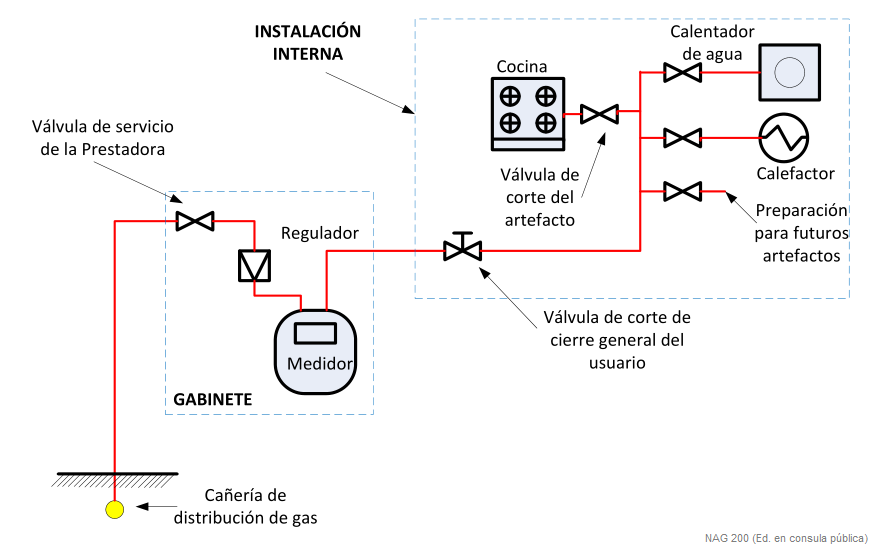

La instalación comienza en la red pública y termina en los artefactos de consumo.

### 3. Componentes principales

- **Acometida:** Es la conexión entre la red de distribución y la vivienda. Generalmente es propiedad de la empresa distribuidora.
- **Medidor de gas:** Mide el volumen de gas consumido. La unidad utilizada normalmente es: **metro cúbico (m³)**

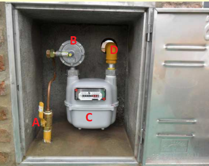

- **Llave de paso general:** Permite cortar el suministro de gas de toda la vivienda. Debe ser accesible y fácil de identificar. Normalmente una llave esférica de un cuarto de vuelta.

[figure not shown]

- **Cañerías internas:** Transportan el gas desde el medidor hasta los distintos artefactos. Pueden ser de:
  - Acero,
  - Cobre,
  - Materiales aprobados por la normativa vigente.

[figure not shown]

- **Llaves de paso individuales:** Cada artefacto debe poseer una llave de corte propia para facilitar tareas de mantenimiento o reparación.

### 4. Artefactos que utilizan gas

Están:

- Cocina
- Calefón: Calienta agua instantáneamente cuando se abre una canilla. No posee tanque de almacenamiento.
- Termotanque: Calienta y almacena agua caliente en un depósito. Puede ser a gas o eléctrico.
- Estufa: Se utiliza para calefaccionar ambientes. Existen distintos tipos:
  - De tiro balanceado ⌕
  - De cámara abierta (toma aire del ambiente) ⌕
  - Sin salida al exterior (los gases de combustión quedan en el ambiente) ⌕
- Horno industrial o doméstico: Utilizado para cocción y panificación.

### 5. Tirajes de los aparatos

Cuando el gas se quema se consume oxígeno y se producen gases que deben eliminarse de forma segura. Se habla de “tiraje” para referirnos a esto

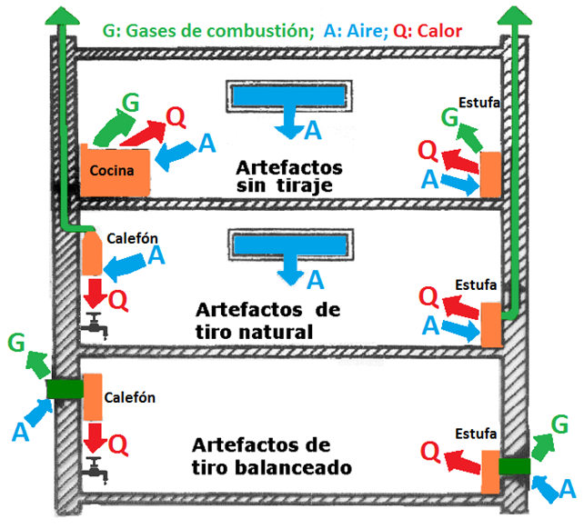

# 7. Estimación simple de consumo de una estufa

Supongamos una estufa de: 3.000 kcal/h. Si funciona durante 5 horas la energía consumida será:

$3000 \cdot 5 = 15.000$ kcal

Como cada metro cúbico aporta aproximadamente (PCI) 9.300 kcal el volumen de gas consumido será:

$\frac{15.000}{9.300}= 1,6$ m3

**Resultado:** la estufa consume aproximadamente **1,6 m³ de gas**.